# Introduction

## The purpose of this report is to describe the data wrangling process of the `WeRateDogs` tweets at twitter.com. This project will wrangle twitter data obtained from different sources.</br>

# Outline:

### 1. Gathering Data

### 2. Assessing Data

### 3. Cleaning Data

## 1. Gathering Data:

### The Data of this project is being collected from different sources using different methods defined below:

#### - **`Twitter Archive`** that contains the archived tweets of @dog_rates under the name `twitter-archive-enhanced.csv`, it's being downloaded manually from Udacity's servers.

#### - **`Image Predictions`** that contains the predictions of the dog breed under the name `image-predictions.tsv`, which is downloaded programmatically from Udacity's servers using requests library in python.

#### - **`Tweets`** that contains the historical tweets of `WeRateDogs` twitter account, which is queried with `twitter API` using tweepy package in python.

## 2. Assessing Data:

### Data collected is being `assessed visually and programmatically` for both `quality and tidiness issues` using various methods explained below:

#### - Data is `visually inspected` using pandas display methods like `.head()`, `.tail()`

#### - `Microsoft Excel` is used to make `detailed visual inspection` for both `quality and tidiness issues.`

#### - Methods like `.info()` is used to `inspect column type` in each data frame.

#### - Libraries like `missingno` is used for `analyzing the missingness of data` in each dataframe (a snapshot of the library's output is viewed below)

#### - Pandas `.value_counts()` is used to analyze quality issues programmatically.

#### - `.duplicated()` is used to find `duplicated data`.

#### Using missingno library to inspect missing data

- We can see that in this `twitter archive` dataframe we have `5 columns with more than 90% of data is missing`

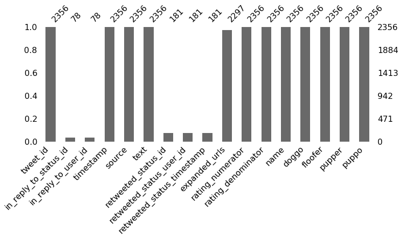

## 3. Cleaning Data:

#### Assessed data is cleaned in 3 stages where we first we define the cleaning process of each assessed issue, second is the actual coding and third is the testing process.

- First and foremost I had created a copy of each dataframe, then dropped all columns with more than 50% of missing values, and dropped duplicated rows using drop_duplicates() method. After this, I had moved into more advanced workflow where I had used fuzzywuzzy package to re-extract the dog stage from the tweet itself.
- Rating is re-extracted from the tweet text using `regular expressions`, and the maximum rating is used when there are multiple ratings in a single tweet, then it is evaluated using `eval` function, multiplied by 10 to get rating numerator. Where numerator is set to 13 when its greater than 13 and set to 1 when its less than 1.
- Untidy dataframes, tiding is done using pandas melt function.
- Columns containing dictionaries, json_normalize is used to extract values to a pandas dataframe.

**Refer to `wrangle_act.html` for detailed description and the actual cleaning process.**

## Conclusion:

> Cleaned data is then stored into SQLite database file, and the cleaned data is used to analyze data, gain insights and make visualizations.</br>

**Refer to `act_report.html` for data insights.**